# Risk Factor Analysis

## Outcome Variable

**Outcome Variable:** wast_rec90d

## Predictor Variables

**Intervention Variable:** nhh

**Adjustment Set:**

- arm
- W_mage
- meducyrs
- feducyrs
- W_mhtcm
- W_mwtkg
- W_mbmi
- W_nrooms
- cleanck
- impfloor
- safeh20
- delta_W_mage
- delta_meducyrs
- delta_feducyrs
- delta_W_mhtcm
- delta_W_mwtkg
- delta_W_mbmi
- delta_W_nrooms
- delta_cleanck
- delta_impfloor
- delta_safeh20

## Stratifying Variables

The analysis was stratified on these variable(s):

- agecat
- studyid
- country

## Data Summary

| agecat | studyid | country | nhh | wast_rec90d | n_cell | n |
| --- | --- | --- | --- | --- | --- | --- |
| 0-24 months | IRC | INDIA | 3 or less | 0 | 17 | 395 |
| 0-24 months | IRC | INDIA | 3 or less | 1 | 32 | 395 |
| 0-24 months | IRC | INDIA | 4-5 | 0 | 61 | 395 |
| 0-24 months | IRC | INDIA | 4-5 | 1 | 75 | 395 |
| 0-24 months | IRC | INDIA | 6-7 | 0 | 47 | 395 |
| 0-24 months | IRC | INDIA | 6-7 | 1 | 60 | 395 |
| 0-24 months | IRC | INDIA | 8+ | 0 | 37 | 395 |
| 0-24 months | IRC | INDIA | 8+ | 1 | 66 | 395 |
| 0-24 months | LCNI-5 | MALAWI | 3 or less | 0 | 16 | 78 |
| 0-24 months | LCNI-5 | MALAWI | 3 or less | 1 | 5 | 78 |
| 0-24 months | LCNI-5 | MALAWI | 4-5 | 0 | 30 | 78 |
| 0-24 months | LCNI-5 | MALAWI | 4-5 | 1 | 4 | 78 |
| 0-24 months | LCNI-5 | MALAWI | 6-7 | 0 | 9 | 78 |
| 0-24 months | LCNI-5 | MALAWI | 6-7 | 1 | 2 | 78 |
| 0-24 months | LCNI-5 | MALAWI | 8+ | 0 | 10 | 78 |
| 0-24 months | LCNI-5 | MALAWI | 8+ | 1 | 2 | 78 |
| 0-24 months | NIH-Birth | BANGLADESH | 3 or less | 0 | 39 | 421 |
| 0-24 months | NIH-Birth | BANGLADESH | 3 or less | 1 | 40 | 421 |
| 0-24 months | NIH-Birth | BANGLADESH | 4-5 | 0 | 88 | 421 |
| 0-24 months | NIH-Birth | BANGLADESH | 4-5 | 1 | 91 | 421 |
| 0-24 months | NIH-Birth | BANGLADESH | 6-7 | 0 | 45 | 421 |
| 0-24 months | NIH-Birth | BANGLADESH | 6-7 | 1 | 55 | 421 |
| 0-24 months | NIH-Birth | BANGLADESH | 8+ | 0 | 30 | 421 |
| 0-24 months | NIH-Birth | BANGLADESH | 8+ | 1 | 33 | 421 |
| 0-24 months | NIH-Crypto | BANGLADESH | 3 or less | 0 | 19 | 310 |
| 0-24 months | NIH-Crypto | BANGLADESH | 3 or less | 1 | 29 | 310 |
| 0-24 months | NIH-Crypto | BANGLADESH | 4-5 | 0 | 63 | 310 |
| 0-24 months | NIH-Crypto | BANGLADESH | 4-5 | 1 | 87 | 310 |
| 0-24 months | NIH-Crypto | BANGLADESH | 6-7 | 0 | 23 | 310 |
| 0-24 months | NIH-Crypto | BANGLADESH | 6-7 | 1 | 46 | 310 |

[output cut: 114 more lines]

The following strata were considered:

- agecat: 0-24 months, studyid: IRC, country: INDIA
- agecat: 0-24 months, studyid: LCNI-5, country: MALAWI
- agecat: 0-24 months, studyid: NIH-Birth, country: BANGLADESH
- agecat: 0-24 months, studyid: NIH-Crypto, country: BANGLADESH
- agecat: 0-24 months, studyid: PROVIDE, country: BANGLADESH
- agecat: 0-24 months, studyid: SAS-FoodSuppl, country: INDIA
- agecat: 0-6 months, studyid: IRC, country: INDIA
- agecat: 0-6 months, studyid: LCNI-5, country: MALAWI
- agecat: 0-6 months, studyid: NIH-Birth, country: BANGLADESH
- agecat: 0-6 months, studyid: NIH-Crypto, country: BANGLADESH
- agecat: 0-6 months, studyid: PROVIDE, country: BANGLADESH
- agecat: 0-6 months, studyid: SAS-FoodSuppl, country: INDIA
- agecat: 6-24 months, studyid: IRC, country: INDIA
- agecat: 6-24 months, studyid: LCNI-5, country: MALAWI
- agecat: 6-24 months, studyid: NIH-Birth, country: BANGLADESH
- agecat: 6-24 months, studyid: NIH-Crypto, country: BANGLADESH
- agecat: 6-24 months, studyid: PROVIDE, country: BANGLADESH
- agecat: 6-24 months, studyid: SAS-FoodSuppl, country: INDIA

### Dropped Strata

Some strata were dropped due to rare outcomes:

- agecat: 0-24 months, studyid: LCNI-5, country: MALAWI
- agecat: 0-24 months, studyid: SAS-FoodSuppl, country: INDIA
- agecat: 0-6 months, studyid: LCNI-5, country: MALAWI
- agecat: 0-6 months, studyid: NIH-Crypto, country: BANGLADESH
- agecat: 0-6 months, studyid: SAS-FoodSuppl, country: INDIA
- agecat: 6-24 months, studyid: LCNI-5, country: MALAWI
- agecat: 6-24 months, studyid: NIH-Crypto, country: BANGLADESH
- agecat: 6-24 months, studyid: PROVIDE, country: BANGLADESH
- agecat: 6-24 months, studyid: SAS-FoodSuppl, country: INDIA

## Methods Detail

We’re interested in the causal parameters $E[Y_a]$ for all values of $a \in \mathcal{A}$. These parameters represent the mean outcome if, possibly contrary to fact, we intervened to set all units to have $A=a$. Under the randomization and positivity assumptions, these are identified by the statistical parameters $\psi_a=E_W[E_{Y|A,W}(Y|A=a,W)]$. In addition, we’re interested in the mean of $Y$, $E[Y]$ under no intervention (the observed mean). We will estimate these parameters by using SuperLearner to fit the relevant likelihood factors – $E_{Y|A,W}(Y|A=a,W)$ and $p(A=a|W)$, and then updating our likelihood fit using a joint TMLE.

For unadjusted analyses ($W=\{\}$), initial likelihoods were estimated using Lrnr_glm to estimate the simple $E(Y|A)$ and Lrnr_mean to estimate $p(A)$. For adjusted analyses, a small library containing Lrnr_glmnet, Lrnr_xgboost, and Lrnr_mean was used.

Having estimated these parameters, we will then use the delta method to estimate relative risks and attributable risks relative to a prespecified baseline level of $A$.

# Results Detail

## Results Plots

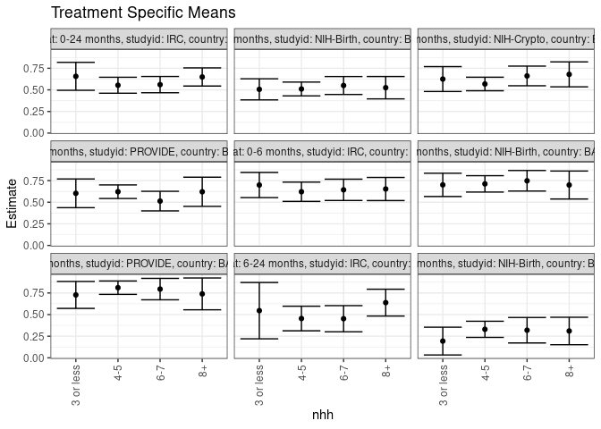

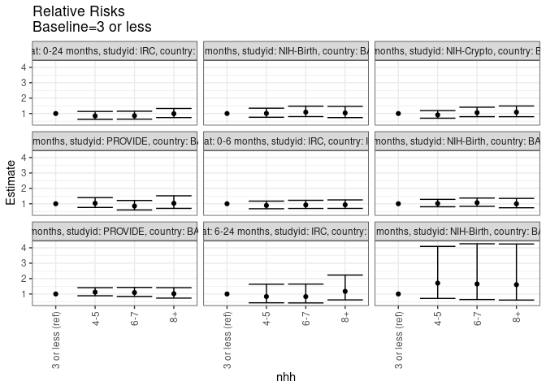

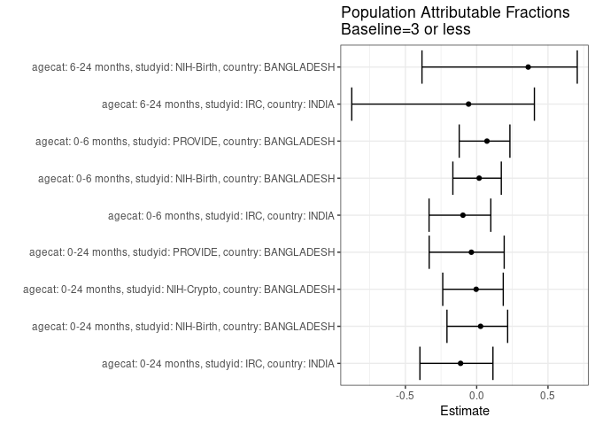

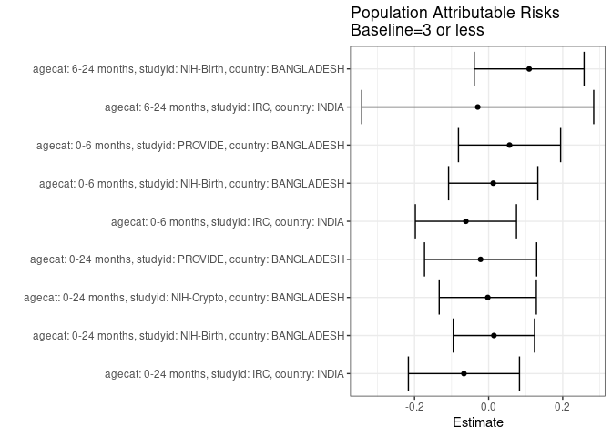

## Results Table

### Parameter: TSM

| agecat | studyid | country | intervention_level | baseline_level | estimate | ci_lower | ci_upper |
| --- | --- | --- | --- | --- | --- | --- | --- |
| 0-24 months | IRC | INDIA | 3 or less | NA | 0.6565187 | 0.4950181 | 0.8180194 |
| 0-24 months | IRC | INDIA | 4-5 | NA | 0.5533562 | 0.4609744 | 0.6457379 |
| 0-24 months | IRC | INDIA | 6-7 | NA | 0.5604842 | 0.4664260 | 0.6545423 |
| 0-24 months | IRC | INDIA | 8+ | NA | 0.6489511 | 0.5441667 | 0.7537355 |
| 0-24 months | NIH-Birth | BANGLADESH | 3 or less | NA | 0.5059765 | 0.3839504 | 0.6280026 |
| 0-24 months | NIH-Birth | BANGLADESH | 4-5 | NA | 0.5100890 | 0.4301252 | 0.5900527 |
| 0-24 months | NIH-Birth | BANGLADESH | 6-7 | NA | 0.5502869 | 0.4467210 | 0.6538528 |
| 0-24 months | NIH-Birth | BANGLADESH | 8+ | NA | 0.5251102 | 0.3956990 | 0.6545215 |
| 0-24 months | NIH-Crypto | BANGLADESH | 3 or less | NA | 0.6248704 | 0.4810611 | 0.7686798 |
| 0-24 months | NIH-Crypto | BANGLADESH | 4-5 | NA | 0.5679279 | 0.4897885 | 0.6460673 |
| 0-24 months | NIH-Crypto | BANGLADESH | 6-7 | NA | 0.6610856 | 0.5474756 | 0.7746956 |
| 0-24 months | NIH-Crypto | BANGLADESH | 8+ | NA | 0.6791875 | 0.5346789 | 0.8236961 |
| 0-24 months | PROVIDE | BANGLADESH | 3 or less | NA | 0.6028837 | 0.4367804 | 0.7689871 |
| 0-24 months | PROVIDE | BANGLADESH | 4-5 | NA | 0.6215280 | 0.5429994 | 0.7000565 |
| 0-24 months | PROVIDE | BANGLADESH | 6-7 | NA | 0.5130499 | 0.3997528 | 0.6263470 |
| 0-24 months | PROVIDE | BANGLADESH | 8+ | NA | 0.6207897 | 0.4522015 | 0.7893780 |
| 0-6 months | IRC | INDIA | 3 or less | NA | 0.6988753 | 0.5533390 | 0.8444117 |
| 0-6 months | IRC | INDIA | 4-5 | NA | 0.6211548 | 0.5096692 | 0.7326405 |
| 0-6 months | IRC | INDIA | 6-7 | NA | 0.6434107 | 0.5201745 | 0.7666470 |
| 0-6 months | IRC | INDIA | 8+ | NA | 0.6529377 | 0.5192764 | 0.7865990 |
| 0-6 months | NIH-Birth | BANGLADESH | 3 or less | NA | 0.7006400 | 0.5660713 | 0.8352088 |
| 0-6 months | NIH-Birth | BANGLADESH | 4-5 | NA | 0.7121029 | 0.6173428 | 0.8068629 |
| 0-6 months | NIH-Birth | BANGLADESH | 6-7 | NA | 0.7478181 | 0.6289370 | 0.8666992 |
| 0-6 months | NIH-Birth | BANGLADESH | 8+ | NA | 0.6989153 | 0.5371534 | 0.8606771 |
| 0-6 months | PROVIDE | BANGLADESH | 3 or less | NA | 0.7272727 | 0.5715327 | 0.8830128 |
| 0-6 months | PROVIDE | BANGLADESH | 4-5 | NA | 0.8111111 | 0.7338113 | 0.8884109 |
| 0-6 months | PROVIDE | BANGLADESH | 6-7 | NA | 0.7948718 | 0.6711274 | 0.9186162 |
| 0-6 months | PROVIDE | BANGLADESH | 8+ | NA | 0.7391304 | 0.5552004 | 0.9230605 |
| 6-24 months | IRC | INDIA | 3 or less | NA | 0.5454545 | 0.2197802 | 0.8711289 |
| 6-24 months | IRC | INDIA | 4-5 | NA | 0.4545455 | 0.3122734 | 0.5968175 |
| 6-24 months | IRC | INDIA | 6-7 | NA | 0.4523810 | 0.3012030 | 0.6035589 |
| 6-24 months | IRC | INDIA | 8+ | NA | 0.6382979 | 0.4831935 | 0.7934023 |
| 6-24 months | NIH-Birth | BANGLADESH | 3 or less | NA | 0.1935484 | 0.0330016 | 0.3540952 |
| 6-24 months | NIH-Birth | BANGLADESH | 4-5 | NA | 0.3296703 | 0.2363549 | 0.4229858 |
| 6-24 months | NIH-Birth | BANGLADESH | 6-7 | NA | 0.3191489 | 0.1718814 | 0.4664164 |
| 6-24 months | NIH-Birth | BANGLADESH | 8+ | NA | 0.3103448 | 0.1515470 | 0.4691427 |

### Parameter: E(Y)

| agecat | studyid | country | intervention_level | baseline_level | estimate | ci_lower | ci_upper |
| --- | --- | --- | --- | --- | --- | --- | --- |
| 0-24 months | IRC | INDIA | NA | NA | 0.5898734 | 0.5376978 | 0.6420491 |
| 0-24 months | NIH-Birth | BANGLADESH | NA | NA | 0.5201900 | 0.4695846 | 0.5707955 |
| 0-24 months | NIH-Crypto | BANGLADESH | NA | NA | 0.6225806 | 0.5684562 | 0.6767051 |
| 0-24 months | PROVIDE | BANGLADESH | NA | NA | 0.5811688 | 0.5245443 | 0.6377934 |
| 0-6 months | IRC | INDIA | NA | NA | 0.6375000 | 0.5751450 | 0.6998550 |
| 0-6 months | NIH-Birth | BANGLADESH | NA | NA | 0.7130045 | 0.6535890 | 0.7724200 |
| 0-6 months | PROVIDE | BANGLADESH | NA | NA | 0.7837838 | 0.7252863 | 0.8422812 |
| 6-24 months | IRC | INDIA | NA | NA | 0.5161290 | 0.4322562 | 0.6000019 |
| 6-24 months | NIH-Birth | BANGLADESH | NA | NA | 0.3030303 | 0.2377927 | 0.3682679 |

### Parameter: RR

| agecat | studyid | country | intervention_level | baseline_level | estimate | ci_lower | ci_upper |
| --- | --- | --- | --- | --- | --- | --- | --- |
| 0-24 months | IRC | INDIA | 3 or less | 3 or less | 1.0000000 | 1.0000000 | 1.000000 |
| 0-24 months | IRC | INDIA | 4-5 | 3 or less | 0.8428642 | 0.6259145 | 1.135012 |
| 0-24 months | IRC | INDIA | 6-7 | 3 or less | 0.8537215 | 0.6336795 | 1.150172 |
| 0-24 months | IRC | INDIA | 8+ | 3 or less | 0.9884731 | 0.7364201 | 1.326796 |
| 0-24 months | NIH-Birth | BANGLADESH | 3 or less | 3 or less | 1.0000000 | 1.0000000 | 1.000000 |
| 0-24 months | NIH-Birth | BANGLADESH | 4-5 | 3 or less | 1.0081278 | 0.7559590 | 1.344414 |
| 0-24 months | NIH-Birth | BANGLADESH | 6-7 | 3 or less | 1.0875740 | 0.8007549 | 1.477128 |
| 0-24 months | NIH-Birth | BANGLADESH | 8+ | 3 or less | 1.0378154 | 0.7348829 | 1.465622 |
| 0-24 months | NIH-Crypto | BANGLADESH | 3 or less | 3 or less | 1.0000000 | 1.0000000 | 1.000000 |
| 0-24 months | NIH-Crypto | BANGLADESH | 4-5 | 3 or less | 0.9088731 | 0.6954729 | 1.187753 |
| 0-24 months | NIH-Crypto | BANGLADESH | 6-7 | 3 or less | 1.0579563 | 0.7947429 | 1.408344 |
| 0-24 months | NIH-Crypto | BANGLADESH | 8+ | 3 or less | 1.0869254 | 0.7933946 | 1.489053 |
| 0-24 months | PROVIDE | BANGLADESH | 3 or less | 3 or less | 1.0000000 | 1.0000000 | 1.000000 |
| 0-24 months | PROVIDE | BANGLADESH | 4-5 | 3 or less | 1.0309251 | 0.7608830 | 1.396807 |
| 0-24 months | PROVIDE | BANGLADESH | 6-7 | 3 or less | 0.8509930 | 0.5971707 | 1.212700 |
| 0-24 months | PROVIDE | BANGLADESH | 8+ | 3 or less | 1.0297006 | 0.6984882 | 1.517969 |
| 0-6 months | IRC | INDIA | 3 or less | 3 or less | 1.0000000 | 1.0000000 | 1.000000 |
| 0-6 months | IRC | INDIA | 4-5 | 3 or less | 0.8887920 | 0.6749382 | 1.170405 |
| 0-6 months | IRC | INDIA | 6-7 | 3 or less | 0.9206374 | 0.6929678 | 1.223106 |
| 0-6 months | IRC | INDIA | 8+ | 3 or less | 0.9342693 | 0.6978846 | 1.250721 |
| 0-6 months | NIH-Birth | BANGLADESH | 3 or less | 3 or less | 1.0000000 | 1.0000000 | 1.000000 |
| 0-6 months | NIH-Birth | BANGLADESH | 4-5 | 3 or less | 1.0163605 | 0.8040122 | 1.284792 |
| 0-6 months | NIH-Birth | BANGLADESH | 6-7 | 3 or less | 1.0673356 | 0.8314881 | 1.370080 |
| 0-6 months | NIH-Birth | BANGLADESH | 8+ | 3 or less | 0.9975383 | 0.7381299 | 1.348113 |
| 0-6 months | PROVIDE | BANGLADESH | 3 or less | 3 or less | 1.0000000 | 1.0000000 | 1.000000 |
| 0-6 months | PROVIDE | BANGLADESH | 4-5 | 3 or less | 1.1152778 | 0.8822429 | 1.409866 |
| 0-6 months | PROVIDE | BANGLADESH | 6-7 | 3 or less | 1.0929487 | 0.8387260 | 1.424228 |
| 0-6 months | PROVIDE | BANGLADESH | 8+ | 3 or less | 1.0163043 | 0.7318877 | 1.411247 |
| 6-24 months | IRC | INDIA | 3 or less | 3 or less | 1.0000000 | 1.0000000 | 1.000000 |
| 6-24 months | IRC | INDIA | 4-5 | 3 or less | 0.8333333 | 0.4246670 | 1.635268 |
| 6-24 months | IRC | INDIA | 6-7 | 3 or less | 0.8293651 | 0.4183925 | 1.644022 |
| 6-24 months | IRC | INDIA | 8+ | 3 or less | 1.1702128 | 0.6142262 | 2.229468 |
| 6-24 months | NIH-Birth | BANGLADESH | 3 or less | 3 or less | 1.0000000 | 1.0000000 | 1.000000 |
| 6-24 months | NIH-Birth | BANGLADESH | 4-5 | 3 or less | 1.7032967 | 0.7092180 | 4.090730 |
| 6-24 months | NIH-Birth | BANGLADESH | 6-7 | 3 or less | 1.6489362 | 0.6381154 | 4.260970 |
| 6-24 months | NIH-Birth | BANGLADESH | 8+ | 3 or less | 1.6034483 | 0.6051792 | 4.248405 |

### Parameter: PAR

| agecat | studyid | country | intervention_level | baseline_level | estimate | ci_lower | ci_upper |
| --- | --- | --- | --- | --- | --- | --- | --- |
| 0-24 months | IRC | INDIA | 3 or less | NA | -0.0666453 | -0.2165979 | 0.0833073 |
| 0-24 months | NIH-Birth | BANGLADESH | 3 or less | NA | 0.0142135 | -0.0955182 | 0.1239452 |
| 0-24 months | NIH-Crypto | BANGLADESH | 3 or less | NA | -0.0022898 | -0.1333950 | 0.1288154 |
| 0-24 months | PROVIDE | BANGLADESH | 3 or less | NA | -0.0217149 | -0.1731342 | 0.1297044 |
| 0-6 months | IRC | INDIA | 3 or less | NA | -0.0613753 | -0.1979094 | 0.0751587 |
| 0-6 months | NIH-Birth | BANGLADESH | 3 or less | NA | 0.0123644 | -0.1081174 | 0.1328463 |
| 0-6 months | PROVIDE | BANGLADESH | 3 or less | NA | 0.0565111 | -0.0814157 | 0.1944378 |
| 6-24 months | IRC | INDIA | 3 or less | NA | -0.0293255 | -0.3424212 | 0.2837702 |
| 6-24 months | NIH-Birth | BANGLADESH | 3 or less | NA | 0.1094819 | -0.0388530 | 0.2578168 |

### Parameter: PAF

| agecat | studyid | country | intervention_level | baseline_level | estimate | ci_lower | ci_upper |
| --- | --- | --- | --- | --- | --- | --- | --- |
| 0-24 months | IRC | INDIA | 3 or less | NA | -0.1129824 | -0.3981130 | 0.1139987 |
| 0-24 months | NIH-Birth | BANGLADESH | 3 or less | NA | 0.0273237 | -0.2083495 | 0.2170319 |
| 0-24 months | NIH-Crypto | BANGLADESH | 3 or less | NA | -0.0036779 | -0.2379671 | 0.1862714 |
| 0-24 months | PROVIDE | BANGLADESH | 3 or less | NA | -0.0373642 | -0.3331809 | 0.1928144 |
| 0-6 months | IRC | INDIA | 3 or less | NA | -0.0962750 | -0.3339547 | 0.0990557 |
| 0-6 months | NIH-Birth | BANGLADESH | 3 or less | NA | 0.0173413 | -0.1670498 | 0.1725991 |
| 0-6 months | PROVIDE | BANGLADESH | 3 or less | NA | 0.0721003 | -0.1224963 | 0.2329616 |
| 6-24 months | IRC | INDIA | 3 or less | NA | -0.0568182 | -0.8760558 | 0.4046741 |
| 6-24 months | NIH-Birth | BANGLADESH | 3 or less | NA | 0.3612903 | -0.3836061 | 0.7051545 |